# Lesson 125 · PyTorch Frame: from typed columns to graph node features

Solution/reference notebook. Solve four functions; checks and the complete F1 path call your implementations. Full historical Table 2 reproduction is NOT_RUN. No hidden repository import or remote trainer is used.

From Lesson 124 to this lesson

We have rows, relationships and prediction requests. Row encoding supplies the numerical vectors that message passing needs.

**Quick prerequisite reminder**

A semantic type describes how a column is interpreted. Materialization applies a fitted vocabulary or statistic; trainable encoding maps that prepared value into a vector.

## 1 · We have a graph and a question. What does each node contain?

[Lesson 122](https://avistian.github.io/relational/lessons/0122-reg-construction.html) made database rows into nodes. [Lesson 123](https://avistian.github.io/relational/lessons/0123-temporal-heterogeneous-graphs.html) restricted their temporal neighborhoods. [Lesson 124](https://avistian.github.io/relational/lessons/0124-entity-task-tables.html) separated prediction queries from entity rows. We still need a differentiable function that turns a driver's nationality, birth date and name into a vector the GNN can consume.

[Lesson 075](https://avistian.github.io/relational/lessons/0075-pytorch-frame-row-encoder.html) established the row-encoder API contract. Here we open its numerical and categorical kernels, verify the ResNet computation, and connect it to real graph features and a differentiable training loss.

**Your tangible win:** materialize typed columns, implement two encoding kernels, preserve entity identity, and trace a training loss back into two table-specific row encoders. You will export features for **every row of the nine-table F1 database censored at 2010-01-01**. The portable notebook contains the actual data, visible code and four live TODO/CHECK tasks.

This serves our [mission](https://avistian.github.io/relational/MISSION.md): to defend an RDL result, you must explain what information enters the model before discussing the power of message passing. A correct graph cannot repair a leaked scaler or vectors attached to the wrong entities.

Primary reading: [Hu et al., PyTorch Frame, §§3–4 and §5.3](https://arxiv.org/html/2404.00776v2). Read Figure 1 first, then follow one numerical and one categorical column through §3. Our API reference is [Frame 0.3.0](https://github.com/pyg-team/pytorch-frame/tree/d998aae368db6a4e36139ccc56bd54579a70874b), pinned independently of the historical paper experiment.

**Route:** Sections 1–7 are the core sitting. Run the notebook and evidence audit in a second sitting. [Student notebook](https://avistian.github.io/relational/labs/0125-pytorch-frame-deep-dive.ipynb) · [Executed solution](https://avistian.github.io/relational/labs/html/0125-pytorch-frame-deep-dive.html) · [Reference](https://avistian.github.io/relational/reference/pytorch-frame-deep-dive.html) · [Reproduction contract](https://avistian.github.io/relational/labs/l125-reproduction.md).

## 2 · A semantic type chooses a computation

A pandas dtype describes storage. A Frame **semantic type**, or `stype`, describes how a model should interpret a column. Integer `statusId` could represent a category; a postal code should not acquire meaning from arithmetic distance. The course schema makes its choices explicit—including treating F1 `statusId` numerically as a deliberate simplification you should challenge.

| Semantic type | Materialized representation | Encoder in this lab | Meaning of the learned operation |
| --- | --- | --- | --- |
| Numerical | Floating values, missing as NaN | `LinearEncoder`, mean imputation | A separate affine embedding per column |
| Categorical | Column-local integer IDs, unknown/missing as −1 | `EmbeddingEncoder` | A separate vocabulary region per column |
| Multicategorical | Ragged lists of category IDs | `MultiCategoricalEmbeddingEncoder` | Pool embeddings within each cell |
| Timestamp | Year and calendar components | `TimestampEncoder` | Year position plus cyclic components, then projection |
| Embedding | Dense vectors, possibly different widths by column | `LinearEmbeddingEncoder` | Project each column to a common width |
| Text embedded | Frozen text vectors, grouped under embedding | Text adapter + projection | Learn from supplied text features |

`text_embedded` is the current code name; the paper also uses `text_embedding`. It shares the embedding parent type in this pinned API. `text_tokenized` is a different route: retain token sequences and allow a text model to train. Our lab does not fine-tune a language model. [Type definitions](https://avistian.github.io/relational/labs/sources/l125/frame/torch_frame/_stype.py) · [encoder source](https://avistian.github.io/relational/labs/sources/l125/frame/torch_frame/nn/encoder/stype_encoder.py).

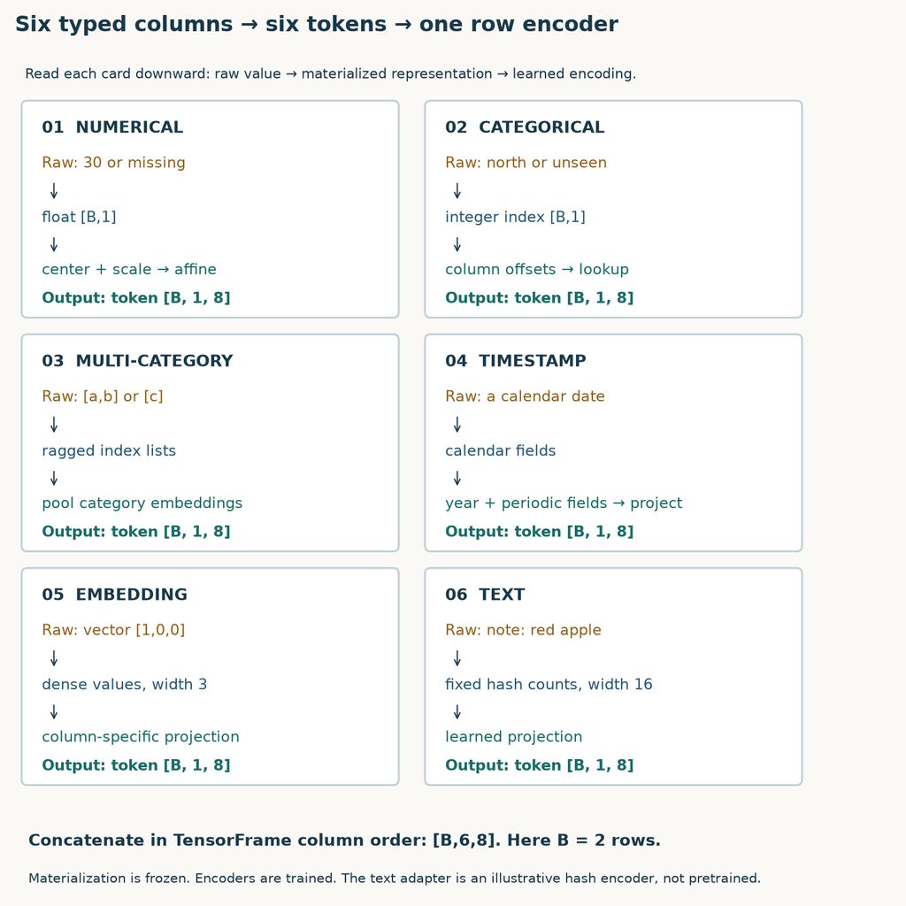

Six semantic-type routes expose raw cells, materialized representations and common-width tokens. Text counts are a fixed illustrative adapter.

**Diagram trace.** Follow one numerical and one categorical column. Separate materialized values from learned tokens and from the final row vector. On a narrow screen, scroll the figure sideways.

**Predict:** can you batch a numerical column and a variable-length tag list into one ordinary rectangular numeric tensor without choosing a representation? Explain what padding or offsets would have to mean. A `TensorFrame` keeps the typed blocks and column names together so that this choice stays explicit.

## 3 · Materialize once; reuse the fitted meaning

Materialization converts cells into tensors and records data-dependent state: numerical statistics, categorical vocabularies, timestamp statistics, and column roles. It is generally preprocessing, outside autograd. The encoder parameters are learned later. Mixing these two kinds of state makes leakage hard to see.

For the small train/query exercise, the correct order is:

```
ds = Dataset(train, col_to_stype=types,
             col_to_text_embedder_cfg=TextEmbedderConfig(fixed_text_vectors))
ds.materialize()
held = ds.convert_to_tensor_frame(query)
```

The query conversion uses the training converter. Concatenating `train` and `query` before materialization changes that converter. Fitting separate converters on each split is also wrong: the same categorical integer could acquire different meanings. [Pinned Dataset implementation](https://avistian.github.io/relational/labs/sources/l125/frame/torch_frame/data/dataset.py).

**TODO 1 — `fit_and_convert`:** return the fitted dataset and query `TensorFrame`. **CHECK:** fitting on `[10,20,30]` keeps mean 20 even if query values change to ±10⁹; an unseen category remains −1. The checker deliberately changes the query population, not merely the output shape.

Static trace: with fitting values 10,20,30, mean=20 and population scale≈8.165. Value30 produces token≈[2.949,−0.725]. Missing maps to bias[0.5,0.5]. Including future value1000 changes the fitted mean to265.

The widget uses population standard deviation, as this Frame release does. With mean imputation, a missing numerical value becomes the training mean and has normalized value zero. That makes its token equal to the learned bias. **It does not give the model an explicit missingness indicator.** If missingness predicts the target, add a separately declared feature and evaluate that change.

For the full F1 course run, dated-table statistics use rows on or before **2004-09-03**, and the frozen converter is applied to rows through 2010-01-01. Static tables are fitted in full because their creation/version histories are absent. That is an explicit historical-validity gap; a stored birth date is not proof that its containing row or mutable attributes were known then.

## 4 · Reconstruct the numerical and categorical kernels

For numerical column j, width d, and row i:

`z[i,j] = (fill(x[i,j], μ[j]) − μ[j]) / scale[j]`

`token[i,j,:] = z[i,j] × weight[j,:] + bias[j,:]`

`scale` is the stored standard deviation plus the release's epsilon. Parameters have shape `[C,d]`; output has shape `[B,C,d]`. Different columns can use different affine maps. The map is linear in the normalized value, but the later residual blocks introduce nonlinear column interactions.

```
filled = torch.where(torch.isnan(raw), mean, raw)
tokens = ((filled - mean) / scale).unsqueeze(-1) * weight + bias
```

**TODO 2 — `numeric_tokens`:** implement this without mutating the raw input. **CHECK:** with supplied mean 20, scale 10, weight `[2,−1]`, bias `[.5,.5]`, value 30 maps to `[2.5,−.5]`; a missing value maps to `[.5,.5]`. These are hand-supplied constants, not a claim that Frame estimates scale 10 from `[10,20,30]`. The checker also tests finite parameter gradients.

Categorical columns require a different operation. Suppose their vocabulary sizes are `[2,3]`. Their offsets are `[0,2]`; reserve index 0 for unknown/missing. Column-local ID 0 maps to global index **1** in the first column and **3** in the second. Without that offset, unrelated categories share a learned vector.

```
offsets = torch.cumsum(sizes, 0) - sizes
indices = torch.where(raw < 0, 0, raw + offsets + 1)
tokens = embedding(indices)
```

**TODO 3 — `categorical_indices`:** apply offsets and reject IDs outside the fitted vocabulary. **CHECK:** `[[0,0],[1,2],[-1,1]]` becomes `[[1,3],[2,5],[0,4]]`. In this configuration padding index 0 is a zero vector and receives no embedding gradient. Unknown and missing are therefore indistinguishable at this encoder; test whether that assumption suits your task. [Exact numerical/categorical kernels](https://avistian.github.io/relational/labs/sources/l125/frame/torch_frame/nn/encoder/stype_encoder.py).

## 5 · Model architecture: how a row becomes a GNN input

Tokens initially describe separate cells. They need to interact before one row vector can summarize them. The visible implementation uses Frame's **ResNet** organization: flatten tokens, pass them through residual blocks, then apply a normalized readout. It is not an attention model.

For the drivers table, six columns at width 8 give `[N,6,8]`, then `[N,48]`. The first block projects 48 values to width 8 and projects the shortcut to the same width. The second block keeps width 8. Each branch applies linear → LayerNorm → ReLU → dropout twice, adds the shortcut, and passes its result onward. The decoder is LayerNorm → ReLU → Linear. Our course run disables dropout to make the trace deterministic.

```
tokens, names = self.tokens(tf)
x = tokens.flatten(1)
x = self.backbone(x)
row_vectors = self.decoder(x)
```

The exact Frame ordering matters: concatenate in **`tf.stypes` order**, and retain the fitted names within each type. Iterating an arbitrary dictionary can yield all the right dimensions and the wrong model. Our source comparison caught precisely this bug. The notebook exposes the residual-block implementation and the pinned upstream source side by side. [Frame ResNet](https://avistian.github.io/relational/labs/sources/l125/frame/torch_frame/nn/models/resnet.py).

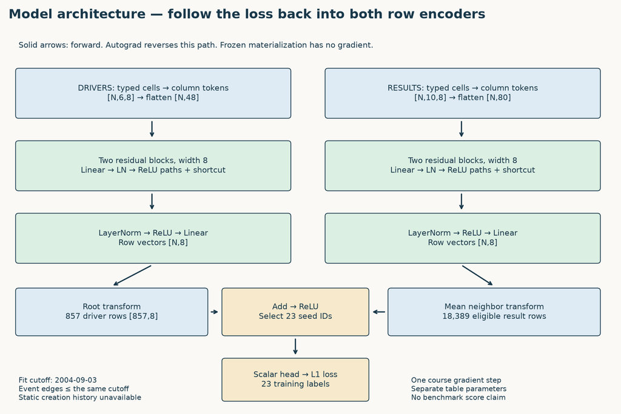

The executed course architecture: separate driver/result ResNets, one mean-GraphSAGE relation, 23 seed predictions and a differentiable loss.

**Diagram trace.** Follow one numerical and one categorical column. Separate materialized values from learned tokens and from the final row vector. On a narrow screen, scroll the figure sideways.

The diagram is the **executed course model**. Driver and result encoders have separate parameters but the same output width. A one-relation GraphSAGE operator averages historical result vectors by `driverId`, transforms root and neighbor vectors separately, adds them, applies ReLU, and predicts only the 23 training seeds. The dated result rows are filtered to the query cutoff before aggregation. The loss reaches both row encoders through differentiable projections and aggregation.

The historical candidate architecture is larger: the archived RelBench code uses four width-128 row blocks, two typed GraphSAGE layers, relative-time encodings and a seed head. The paper names Frame ResNet + HeteroSAGE, but does not attest this exact source snapshot. **Neither the small course model nor this source resemblance establishes its Table 2 result.** [Archived candidate model](https://avistian.github.io/relational/labs/sources/l125/relbench/examples/model.py) · [typed encoder/GNN](https://avistian.github.io/relational/labs/sources/l125/relbench/relbench/external/nn.py).

**Predict:** modify a different driver's row. With LayerNorm and dropout disabled, your row encoder output should stay unchanged. Modify one of your driver's historical result rows: the GNN prediction may change. Column interaction and graph interaction operate along different axes.

## 6 · Preserve identity across the encoder–GNN boundary

The output contract is richer than `[N,d]`. It includes table identity, entity IDs, column roles, fitted statistics, model parameters and the information cutoff. An embedding file with no IDs cannot safely be attached to a graph after sorting or filtering.

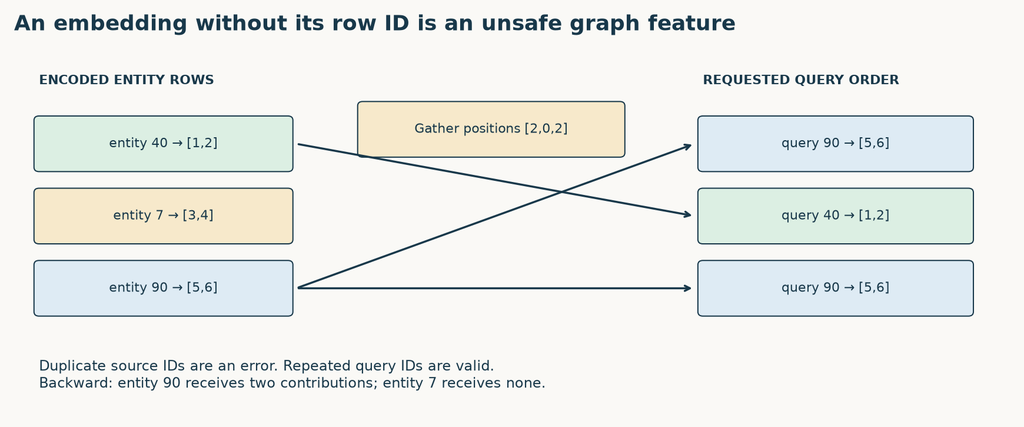

Entity IDs preserve alignment under reordered and repeated queries; duplicate requests accumulate gradients to their source row.

**TODO 4 — `align_rows`:** gather encoded rows by requested entity IDs. Duplicate IDs in the source export are invalid; repeated requested IDs are legal. **CHECK:** source IDs `[40,7,90]` and requests `[90,40,90]` gather positions `[2,0,2]`. The backward check gives entity 90 two gradient contributions. Indexing by an ID value or assuming request order equals storage order must fail.

For the full export, every table is deliberately reversed and then realigned by ID. The independent audit also compares all vectors against the upstream Frame forward pass with identical weights. The lab uses primary and foreign keys as structure, removes the table's event-time column from row features, and keeps the time boundary separately. Other meaningful timestamp features, such as date of birth, still use a timestamp encoder.

A cached node embedding is valid only for the encoder state that produced it. If the GNN is training the row encoder end to end, repeatedly reusing detached precomputed vectors would cut that gradient path. The exported file is an inspection artifact; the gradient exercise recomputes live vectors.

## 7 · Execute the complete course feature path

**Author-reference execution: complete course feature path, not a paper-score reproduction.**

| Table | Fitting rows | Encoded rows | Columns | Output width |
| --- | --- | --- | --- | --- |
| constructor_results | 8,441 | 9,408 | 1 | 8 |
| constructor_standings | 9,189 | 10,170 | 3 | 8 |
| circuits | 77 | 77 | 7 | 8 |
| qualifying | 2,148 | 4,082 | 2 | 8 |
| drivers | 857 | 857 | 6 | 8 |
| results | 18,389 | 20,323 | 10 | 8 |
| races | 727 | 820 | 4 | 8 |
| standings | 25,999 | 28,115 | 3 | 8 |
| constructors | 211 | 211 | 3 | 8 |

Total **74,063 rows**. Maximum difference from the upstream Frame forward pass with identical weights: **0**. All IDs and finite-value checks passed. The separate one-step exercise used **23 training queries**, **18,389 eligible result rows**, and updated **58 parameter tensors**. [Measured report](https://avistian.github.io/relational/labs/evidence/l125/summary.json) · [Independent audit](https://avistian.github.io/relational/labs/_audit_l125_results.json).

The notebook runs from an empty directory with embedded, checksum-verified F1 database and task archives. It materializes all nine tables, calls your numerical/categorical kernels, gathers by your identity function, and exports `l125-encoded-reg.npz`. Each table has an `*_ids` array and `*_vectors` array. `l125-feature-report.json` records shapes, fitting populations and one-step gradient evidence.

The gradient step uses the released **training** task rows at 2004-09-03 and only result events no later than that cutoff. Its 23 labels supervise the seed outputs. Labels never enter the row features. Initial loss is recorded solely as a debugging observation; there is no test-set performance estimate from one optimizer step.

**Read the limitations before interpreting the export:** width 8, two residual blocks, deterministic 16-bin hashed text counts, random initial weights, a single graph relation for the gradient step, and no static creation history. Text hashing has collisions and no pretrained semantics. Real F1 data exercise numerical, categorical, timestamp and embedded-text paths; the six-type fixture separately covers multicategorical and external vectors. These are useful implementation tests, not the published Stack Exchange experiment.

**Inspect an actual text collision.** The course's `fixed_text_vectors` hashes each lowercase word into one of 16 bins and counts it. With this exact adapter, both `cat` and `fox` land in bin 7 (zero-based):

| Text | Bin 7 | Other bins |
| --- | --- | --- |
| cat | 1 | All 0 |
| fox | 1 | All 0 |
| cat cat | 2 | All 0 |

The first two texts become the same 16-number input. No learned projection of that vector can recover which word was present. If all other inputs and graph context are also identical, downstream training cannot separate them using this lost distinction. This is a property of our small deterministic adapter, not a claim about pretrained text encoders. You can inspect the hash and counting code in the [visible implementation](https://avistian.github.io/relational/labs/relkit/frame_l125.py).

**Try the change.** What vector does `cat fox` produce? Would training the row ResNet for more epochs recover the difference between that string and `cat cat`?

**Check the input boundary**

Both strings put count 2 in bin 7 and zero elsewhere. More training cannot undo an identical input representation. A different vocabulary or text encoder could preserve this distinction; its effectiveness would need a separate evaluation. Repetition counts surviving does not mean word identity survived.

## 8 · Full reproduction audit: what is actually recoverable?

The selected target is **Hu et al. Table 2, `rel-stackex-engage`: ROC-AUC 0.854**. It predicts whether a user contributes a vote, comment or post over the next two years. The contemporaneous source implements a 730-day window, with validation at 2019-01-01 and test at 2021-01-01. [Paper §5.3/Table 2](https://arxiv.org/html/2404.00776v2#S5.SS3) · [archived task SQL](https://avistian.github.io/relational/labs/sources/l125/relbench/relbench/tasks/stackex.py).

**Current result: `NOT_RUN`.** On 2026-09-27, all six probed historical/archive endpoints returned HTTP 404, including the original database, task and raw-data paths. The original SHA-256 identities are retained in the audit, but no matching archive was recovered. This finding is bounded to the checked sources; it is not proof that nobody has a private or archival copy. [Probe evidence](https://avistian.github.io/relational/labs/_paper_audit_l125_results.json).

There are protocol gaps even if the data are recovered. The paper does not identify a precise source commit/seed ensemble. The archived example regenerates labels with `process=True`, uses an unpinned GloVe sentence-transformer revision, and has no historical environment lock. A modern task with a similar name does not close these gaps.

| Evidence | State | What it establishes |
| --- | --- | --- |
| Four learner contract checks + mutation failures | PASS | Correct tested mechanisms and failure detection |
| Frame outputs, gradients, Adam update | MATCH | Current pinned operator/model parity |
| Every F1 node-feature row | PASS | Complete course feature path, same-weight reference agreement |
| Real training-query gradient step | PASS | Loss reaches two table-specific encoders |
| Historical Stack Exchange target | NOT_RUN | No recovered checksum-matching input; no measured ROC-AUC |
| Historical binary/whole-paper reproduction | NOT_ESTABLISHED | Source resemblance is insufficient |
| Live Colab / deployment | NOT_CHECKED | Local notebook/browser checks are separate |
| Learner mastery | PENDING_WRITTEN_DEFENSE | Author execution is not your exit artifact |

The [reproduction contract](https://avistian.github.io/relational/labs/l125-reproduction.md) includes exact commands, pinned model/trainer sources, the recovery preflight, source assumptions and compute ledger. Paid compute used: **$0**. The approved **$10 aggregate cap** remains unused; launching a different benchmark would not reproduce this target.

## 9 · Retrieval, interventions and your exit artifact

Close the notebook and answer before checking the implementation:

1. Why can a categorical ID of zero mean different things in two columns? Derive the offset for a third column with vocabulary size 4 after columns of sizes 2 and 3.
2. Under mean imputation, what numerical token represents missingness? How would you preserve a separate missingness signal?
3. Which fitted state changes if future rows are included, even when their labels are hidden? Give one numerical and one categorical example.
4. Why does the first residual block need a shortcut projection for six width-8 tokens? Which axis mixes columns, and which operation later mixes rows?
5. Why can repeated query IDs be correct while repeated source entity IDs are wrong? Show the backward accumulation for `[90,40,90]`.
6. Which evidence is still missing before you could compare a score with 0.854? Distinguish archive identity, protocol identity, runtime identity and metric computation.

**EXIT submission:** your four implementations, the exported node features with IDs, the JSON report, and a one-page explanation of the six questions. Add one deliberate intervention: remove categorical offsets, contaminate fitted statistics, shuffle vectors without IDs, or detach one encoder before the graph loss. Predict the failure, run it, and explain the observed result. Do not overwrite the correct baseline.

A passing solution notebook is author-reference evidence. Your status remains **PENDING_WRITTEN_DEFENSE** until you can explain and defend the computation. Revisit questions 2, 4 and 5 tomorrow without notes; revisit the archive/protocol distinction next week.

Explain why tensor shapes cannot establish correct preprocessing or entity alignment.

Ask the agent follow-up questions whenever a tensor, fitted statistic or gradient edge is unclear. Next, the separately planned **L125b Universal Row Encoder** asks how to decouple the encoder from a particular graph stack; L126 examines the RelBench beta paper. This lesson prepares the interface needed for both.

**Carry this forward.** Use the benchmark API to keep database inputs, task questions and evaluation aligned. [Continue to Lesson 126](https://avistian.github.io/relational/lessons/0126-relbench-beta.html).

## SETUP

The proposed Colab bootstrap installs dependencies only in Colab. Live Colab is NOT_CHECKED. Locally, use the recorded author environment. The pinned Frame conversion may emit a pandas3 read-only NumPy warning; our numeric/categorical kernels do not mutate those inputs.

```python
# @colab-bootstrap: optional proposed Colab runtime; local author runtime is recorded separately.
import sys,subprocess,platform
if 'google.colab' in sys.modules:
    subprocess.check_call([sys.executable,'-m','pip','install','-q',
        'torch==2.5.1','pytorch-frame==0.3.0','numpy==1.26.4','pandas==2.2.3','pyarrow==18.1.0'])
import torch,torch_frame,pandas as pd
assert torch_frame.__version__=='0.3.0', 'Use the pinned Frame API'
print({'python':platform.python_version(),'torch':torch.__version__,'frame':torch_frame.__version__,'pandas':pd.__version__})
```

```
{'python': '3.12.3', 'torch': '2.13.0+cpu', 'frame': '0.3.0', 'pandas': '3.0.3'}
```

```python
"""Visible L125 mechanisms; course experiment, not Hu Table 2 reproduction.

Frame 0.3.0 reference implementation is pinned in sources/l125/frame.
The four learner functions are also used by the real-data pipeline.
"""
import hashlib
import re
import numpy as np
import pandas as pd
import torch
from torch import nn
from torch_frame import stype, NAStrategy
from torch_frame.config import TextEmbedderConfig
from torch_frame.data import Dataset
from torch_frame.data.stats import StatType
from torch_frame.nn import (LinearEncoder, EmbeddingEncoder, TimestampEncoder,
    LinearEmbeddingEncoder, MultiCategoricalEmbeddingEncoder, StypeWiseFeatureEncoder)
```

## TODO · `numeric_tokens`

Reconstruct normalization, mean imputation and the column-specific affine map. Predict the CHECK output before running it.

```python
def numeric_tokens(raw, mean, scale, weight, bias):
    """[B,C] -> [B,C,d]; scale already includes the upstream epsilon."""
    filled=torch.where(torch.isnan(raw),mean,raw)
    return ((filled-mean)/scale).unsqueeze(-1)*weight + bias
```

```python
def check_numeric(fn=numeric_tokens):
    raw=torch.tensor([[30.,float('nan')],[10.,4.]])
    mean=torch.tensor([20.,4.]);scale=torch.tensor([10.,2.])
    w=torch.tensor([[2.,-1.],[3.,2.]],requires_grad=True);b=torch.tensor([[.5,.5],[1.,-1.]],requires_grad=True)
    out=fn(raw,mean,scale,w,b)
    torch.testing.assert_close(out,torch.tensor([[[2.5,-.5],[1.,-1.]],[[-1.5,1.5],[1.,-1.]]]))
    out.sum().backward();assert torch.isfinite(w.grad).all() and torch.isfinite(b.grad).all()
    assert torch.isnan(raw[0,1]),'Do not mutate raw data'
    return 'PASS'
check_numeric(numeric_tokens)
print("PASS: numeric_tokens")
```

```
PASS: numeric_tokens
```

## TODO · `categorical_indices`

Reserve padding index zero and separate column vocabularies with offsets. Predict the CHECK output before running it.

```python
def categorical_indices(raw, cardinalities):
    """Disjoint column vocabularies; all negative IDs share padding index 0."""
    sizes=torch.as_tensor(cardinalities,device=raw.device,dtype=torch.long)
    if raw.ndim!=2 or raw.shape[1]!=len(sizes) or (sizes<0).any():
        raise ValueError('Column cardinality mismatch')
    if (raw>=sizes).any():raise ValueError('ID outside fitted vocabulary')
    offsets=torch.cumsum(sizes,0)-sizes
    return torch.where(raw<0,0,raw+offsets+1)
```

```python
def check_categories(fn=categorical_indices):
    raw=torch.tensor([[0,0],[1,2],[-1,1],[0,-1]])
    torch.testing.assert_close(fn(raw,[2,3]),torch.tensor([[1,3],[2,5],[0,4],[1,0]]))
    assert torch.equal(raw,torch.tensor([[0,0],[1,2],[-1,1],[0,-1]]))
    try:fn(torch.tensor([[2,0]]),[2,3])
    except ValueError:pass
    else:raise AssertionError('Reject category IDs outside fitted vocabulary')
    return 'PASS'
check_categories(categorical_indices)
print("PASS: categorical_indices")
```

```
PASS: categorical_indices
```

## TODO · `align_rows`

Gather using immutable entity IDs, preserving duplicate requests and rejecting duplicate sources. Predict the CHECK output before running it.

```python
def align_rows(row_ids, encoded, requested_ids):
    """Gather by immutable entity ID; repeated query IDs are legitimate."""
    if len(row_ids)!=len(encoded):raise ValueError('Row count mismatch')
    lookup={key:i for i,key in enumerate(row_ids)}
    if len(lookup)!=len(row_ids):raise ValueError('Duplicate source row ID')
    if any(key not in lookup for key in requested_ids):raise ValueError('Unknown row ID')
    positions=torch.tensor([lookup[key] for key in requested_ids],device=encoded.device,dtype=torch.long)
    return encoded[positions]
```

```python
def check_alignment(fn=align_rows):
    z=torch.tensor([[1.,2.],[3.,4.],[5.,6.]],requires_grad=True)
    y=fn([40,7,90],z,[90,40,90]);torch.testing.assert_close(y,torch.tensor([[5.,6.],[1.,2.],[5.,6.]]))
    y.sum().backward();torch.testing.assert_close(z.grad,torch.tensor([[1.,1.],[0.,0.],[2.,2.]]))
    for ids,requested in [([40,40,90],[40]),([40,7,90],[999])]:
        try:fn(ids,z,requested)
        except ValueError:pass
        else:raise AssertionError('Reject duplicate source IDs / missing requests')
    return 'PASS'
check_alignment(align_rows)
print("PASS: align_rows")
```

```
PASS: align_rows
```

### PROVIDED · `fixed_text_vectors`

Read the implementation and trace its inputs to outputs.

```python
def fixed_text_vectors(texts):
    """Deterministic 16-bin token counts: a visible adapter, NOT pretrained text.

    This deliberately avoids network/model dependencies in the course path.
    Collisions and lack of semantics are limitations, not a paper approximation.
    """
    out=torch.zeros(len(texts),16)
    for i,text in enumerate(texts):
        for word in re.findall(r'\w+',str(text).lower()):
            bucket=int.from_bytes(hashlib.sha256(word.encode()).digest()[:4],'little')%16
            out[i,bucket]+=1
    return out
```

## TODO · `fit_and_convert`

Fit on the training population, then reuse the converter for query rows. Predict the CHECK output before running it.

```python
def fit_and_convert(train, query, types):
    """Fit dictionaries/statistics only on the supplied fitting rows."""
    ds=Dataset(train,col_to_stype=types,
               col_to_text_embedder_cfg=TextEmbedderConfig(fixed_text_vectors))
    ds.materialize()
    return ds,ds.convert_to_tensor_frame(query)
```

```python
def check_fit(fn=fit_and_convert):
    tr=pd.DataFrame({'x':[10.,20.,30.],'c':['a','b','a']});q=pd.DataFrame({'x':[1000.,None],'c':['future',None]})
    ds,tf=fn(tr,q,{'x':stype.numerical,'c':stype.categorical})
    assert ds.col_stats['x'][StatType.MEAN]==20
    assert tf.feat_dict[stype.categorical].tolist()==[[-1],[-1]]
    q.x=[1e9,-1e9];other,_=fn(tr,q,{'x':stype.numerical,'c':stype.categorical})
    assert ds.col_stats==other.col_stats,'Query values changed fitted state'
    return 'PASS'
check_fit(fit_and_convert)
print("PASS: fit_and_convert")
```

```
PASS: fit_and_convert
```

### PROVIDED · `encoder_recipe`

Read the implementation and trace its inputs to outputs.

```python
def encoder_recipe():
    """Fresh instances per table; text_embedded is grouped under embedding."""
    return {stype.numerical:LinearEncoder(na_strategy=NAStrategy.MEAN),
            stype.categorical:EmbeddingEncoder(),
            stype.multicategorical:MultiCategoricalEmbeddingEncoder(),
            stype.timestamp:TimestampEncoder(),
            stype.embedding:LinearEmbeddingEncoder()}
```

### PROVIDED · `VisibleResidualBlock`

Read the implementation and trace its inputs to outputs.

```python
class VisibleResidualBlock(nn.Module):
    """Frame FCResidualBlock equations, with LayerNorm and configurable dropout."""
    def __init__(self,input_width,width,dropout):
        super().__init__()
        self.lin1=nn.Linear(input_width,width);self.lin2=nn.Linear(width,width)
        self.norm1=nn.LayerNorm(width);self.norm2=nn.LayerNorm(width)
        self.dropout=nn.Dropout(dropout)
        self.shortcut=nn.Linear(input_width,width) if input_width!=width else None
    def forward(self,x):
        out=self.dropout(torch.relu(self.norm1(self.lin1(x))))
        out=self.dropout(torch.relu(self.norm2(self.lin2(out))))
        return out+(self.shortcut(x) if self.shortcut is not None else x)
```

### PROVIDED · `VisibleRowResNet`

Read the implementation and trace its inputs to outputs.

```python
class VisibleRowResNet(nn.Module):
    """Typed tokens -> flatten -> residual blocks -> normalized row readout.

    Same state keys and equations as pinned Frame ResNet (LayerNorm setting).
    Numeric and categorical kernels call the learner's functions. Other typed
    kernels remain the pinned library primitives, shown in the notebook appendix.
    """
    def __init__(self,ds,width=8,out_width=8,layers=2,dropout=0.):
        super().__init__()
        self.encoder=StypeWiseFeatureEncoder(out_channels=width,col_stats=ds.col_stats,
            col_names_dict=ds.tensor_frame.col_names_dict,stype_encoder_dict=encoder_recipe())
        self.backbone=nn.Sequential(*[VisibleResidualBlock(ds.tensor_frame.num_cols*width if i==0 else width,width,dropout) for i in range(layers)])
        self.decoder=nn.Sequential(nn.LayerNorm(width),nn.ReLU(),nn.Linear(width,out_width))
    def tokens(self,tf):
        pieces=[];names=[]
        for kind in tf.stypes:
            columns=self.encoder.col_names_dict[kind]
            enc=self.encoder.encoder_dict[kind.value];raw=tf.feat_dict[kind]
            if kind==stype.numerical:
                out=numeric_tokens(raw,enc.mean,enc.std,enc.weight,enc.bias)
            elif kind==stype.categorical:
                # Offsets are stored in the source encoder; lengths come from stats.
                from torch_frame.data.stats import StatType
                counts=[len(s[StatType.COUNT][0]) for s in enc.stats_list]
                out=enc.emb(categorical_indices(raw,counts))
            else:out=enc(raw,columns)
            pieces.append(out);names.extend(columns)
        return torch.cat(pieces,dim=1),names
    def forward(self,tf):
        tokens,_=self.tokens(tf)
        return self.decoder(self.backbone(tokens.flatten(1)))
```

### PROVIDED · `typed_fixture`

Read the implementation and trace its inputs to outputs.

```python
def typed_fixture():
    train=pd.DataFrame({'amount':[10.,20.,30.,np.nan], 'region':['north','south','north','south'],
        'note':['red apple','green apple','red pear','green pear'],
        'created':pd.to_datetime(['2024-01-01','2024-01-02','2024-02-01','2024-02-02']),
        'vector':[[1.,0.,0.],[0.,1.,0.],[0.,0.,1.],[1.,1.,0.]],
        'tags':[['a','b'],['b'],['c'],['a']]})
    query=train.iloc[[2,0]].copy();query.loc[query.index[0],'region']='unseen';query.loc[query.index[1],'amount']=np.nan
    types={'amount':stype.numerical,'region':stype.categorical,'note':stype.text_embedded,
        'created':stype.timestamp,'vector':stype.embedding,'tags':stype.multicategorical}
    return train,query,types
```

### PROVIDED · `mean_messages`

Read the implementation and trace its inputs to outputs.

```python
def mean_messages(source,edges,num_targets):
    """Visible one-relation mean aggregation; edges [2,E] source -> target."""
    out=source.new_zeros((num_targets,source.shape[1]));degree=source.new_zeros(num_targets)
    out.index_add_(0,edges[1],source[edges[0]])
    degree.index_add_(0,edges[1],torch.ones(edges.shape[1],device=source.device))
    return out/degree.clamp_min(1).unsqueeze(-1)
```

### PROVIDED · `CourseGraphHead`

Read the implementation and trace its inputs to outputs.

```python
class CourseGraphHead(nn.Module):
    """One typed results -> drivers GraphSAGE relation; no temporal sampler.

    All edges passed here must already be filtered to one cutoff. This is a
    gradient/interface exercise, not the historical two-layer heterogeneous GNN.
    """
    def __init__(self,width):
        super().__init__();self.root=nn.Linear(width,width);self.neighbor=nn.Linear(width,width,bias=False);self.head=nn.Linear(width,1)
    def forward(self,drivers,results,edges,seeds):
        messages=mean_messages(results,edges,len(drivers))
        hidden=torch.relu(self.root(drivers)+self.neighbor(messages))
        return self.head(hidden[seeds]).flatten()
```

```python
F1_SCHEMA={
 'constructor_results':{'points':'numerical'},
 'constructor_standings':{'points':'numerical','position':'numerical','wins':'numerical'},
 'circuits':{'circuitRef':'text_embedded','name':'text_embedded','location':'text_embedded','country':'categorical','lat':'numerical','lng':'numerical','alt':'numerical'},
 'qualifying':{'number':'numerical','position':'numerical'},
 'drivers':{'driverRef':'text_embedded','code':'categorical','forename':'text_embedded','surname':'text_embedded','dob':'timestamp','nationality':'categorical'},
 'results':{c:'numerical' for c in ['number','grid','position','positionOrder','points','laps','milliseconds','fastestLap','rank','statusId']},
 'races':{'year':'numerical','round':'numerical','name':'text_embedded','time':'categorical'},
 'standings':{'points':'numerical','position':'numerical','wins':'numerical'},
 'constructors':{'constructorRef':'text_embedded','name':'text_embedded','nationality':'categorical'}}
```

```python
F1_KEYS={'constructor_results':'constructorResultsId','constructor_standings':'constructorStandingsId','circuits':'circuitId','qualifying':'qualifyId','drivers':'driverId','results':'resultId','races':'raceId','standings':'driverStandingsId','constructors':'constructorId'}
```

### PROVIDED · `load_f1_archive`

Read the implementation and trace its inputs to outputs.

```python
def load_f1_archive(raw):
    """Checksum-verified released data; filter dated tables to Jan 1, 2010."""
    import io,zipfile
    digest='ec31a4e1bc2b2f9c36c05fcd3dfe2a40a506f335dc51ce79c3ec8bb40feb1482'
    if hashlib.sha256(raw).hexdigest()!=digest:raise ValueError('Unexpected F1 archive')
    tables={}
    with zipfile.ZipFile(io.BytesIO(raw)) as z:
        for name in F1_SCHEMA:
            path=next(p for p in z.namelist() if p.endswith('/'+name+'.parquet') or p==name+'.parquet')
            df=pd.read_parquet(io.BytesIO(z.read(path)))
            if 'date' in df:df=df.loc[df.date<=pd.Timestamp('2010-01-01')].copy()
            tables[name]=df.reset_index(drop=True)
    return tables
```

### PROVIDED · `encode_f1_tables`

Read the implementation and trace its inputs to outputs.

```python
def encode_f1_tables(tables,fit_cutoff='2004-09-03'):
    """All nine tables, width 8, two residual blocks, random initialization.

    Dated-table statistics use rows <= fit_cutoff. Static tables have no creation
    history and are fit in full; therefore point-in-time validity is unestablished.
    Returns exportable vectors and live models/TensorFrames for the gradient lab.
    """
    torch.manual_seed(125);torch.set_num_threads(2)
    models={};frames={};exports={};report={}
    for name,table in tables.items():
        types={c:getattr(stype,t) for c,t in F1_SCHEMA[name].items()}
        features=table[list(types)].copy()
        for c,t in types.items():
            if t==stype.numerical:features[c]=pd.to_numeric(features[c],errors='coerce').astype(float)
            elif t in (stype.categorical,stype.text_embedded):features[c]=features[c].fillna('').astype(str)
        fit_mask=table.date<=pd.Timestamp(fit_cutoff) if 'date' in table else pd.Series(True,index=table.index)
        if not fit_mask.any():raise ValueError('No fitting rows for '+name)
        ds,tf=fit_and_convert(features.loc[fit_mask].copy(),features,types)
        model=VisibleRowResNet(ds).eval()
        with torch.no_grad():
            vectors=torch.cat([model(tf[i:i+1024]) for i in range(0,len(table),1024)])
        if not torch.isfinite(vectors).all():raise ValueError('Nonfinite embeddings: '+name)
        ids=table[F1_KEYS[name]].astype(int).tolist()
        # Prove alignment survives a shuffled export, rather than merely count rows.
        permutation=torch.arange(len(ids)-1,-1,-1)
        restored=align_rows([ids[i] for i in permutation],vectors[permutation],ids)
        torch.testing.assert_close(restored,vectors)
        models[name]=model;frames[name]=tf;exports[name]={'ids':ids,'vectors':vectors}
        report[name]={'rows':len(table),'fit_rows':int(fit_mask.sum()),'columns':{c:t.value for c,t in types.items()},'token_shape':[len(table),len(types),8],'row_shape':list(vectors.shape),'identity_check':'PASS','finite':'PASS','fit_boundary':fit_cutoff if 'date' in table else 'STATIC_HISTORY_UNAVAILABLE'}
    return models,frames,exports,report
```

### PROVIDED · `gradient_step`

Read the implementation and trace its inputs to outputs.

```python
def gradient_step(tables,models,frames,task_bytes,cutoff='2004-09-03'):
    """One update on 23 released TRAIN queries, for gradient evidence only."""
    import io,zipfile
    expected='775b28a51604169539bbe712a2f0d15158c112bc6abf316cdd0995087a7ae03e'
    if hashlib.sha256(task_bytes).hexdigest()!=expected:raise ValueError('Unexpected task archive')
    with zipfile.ZipFile(io.BytesIO(task_bytes)) as z:
        task=pd.read_parquet(io.BytesIO(z.read('driver-position/train.parquet')))
    task=task.loc[task.date==pd.Timestamp(cutoff)].copy().sort_values('driverId')
    if len(task)==0:raise ValueError('No training queries')
    driver_ids=tables['drivers'].driverId.astype(int).tolist();lookup={key:i for i,key in enumerate(driver_ids)}
    eligible=(tables['results'].date<=pd.Timestamp(cutoff)) & tables['results'].driverId.notna()
    positions=np.flatnonzero(eligible.to_numpy());r=tables['results'].iloc[positions]
    edges=torch.tensor([list(range(len(r))),[lookup[int(k)] for k in r.driverId]],dtype=torch.long)
    seeds=torch.tensor([lookup[int(k)] for k in task.driverId])
    target=torch.tensor(task.position.to_numpy(),dtype=torch.float32)
    head=CourseGraphHead(8);params=list(models['drivers'].parameters())+list(models['results'].parameters())+list(head.parameters())
    optimizer=torch.optim.Adam(params,lr=.001);optimizer.zero_grad()
    drivers=models['drivers'](frames['drivers']);results=models['results'](frames['results'][torch.as_tensor(positions)])
    prediction=head(drivers,results,edges,seeds);loss=torch.nn.functional.l1_loss(prediction,target);loss.backward()
    norms={name:float(sum(p.grad.abs().sum() for p in models[name].parameters() if p.grad is not None)) for name in ['drivers','results']}
    if not all(v>0 and np.isfinite(v) for v in norms.values()):raise ValueError('Broken encoder gradients')
    before=[p.detach().clone() for p in params];optimizer.step()
    changed=sum(not torch.equal(a,b) for a,b in zip(before,params))
    if not changed:raise ValueError('No parameter update')
    return {'status':'PASS','training_queries':len(task),'cutoff':cutoff,'visible_results':len(r),'max_input_time':str(r.date.max()),'loss_before_one_step':float(loss.detach()),'encoder_gradient_l1':norms,'changed_parameter_tensors':changed,'metric_status':'NOT_A_BENCHMARK','static_history':'UNAVAILABLE'}
```

## CHECK · pinned Frame parity

This independently compares typed tokens, row vectors, parameter gradients and one Adam update on a six-type fixture. It also checks row permutation and row locality in evaluation mode.

```python
from torch_frame.nn.models import ResNet
def check_model():
    torch.manual_seed(125);tr,q,types=typed_fixture();ds,tf=fit_and_convert(tr,q,types)
    ours=VisibleRowResNet(ds);ref=ResNet(channels=8,out_channels=8,num_layers=2,col_stats=ds.col_stats,col_names_dict=ds.tensor_frame.col_names_dict,stype_encoder_dict=encoder_recipe(),dropout_prob=0.)
    ref.load_state_dict(ours.state_dict());ours.eval();ref.eval()
    a,names=ours.tokens(tf);b,expected_names=ref.encoder(tf)
    assert names==expected_names,(names,expected_names)
    torch.testing.assert_close(a,b,rtol=1e-6,atol=1e-6)
    x=ours(tf);y=ref(tf);torch.testing.assert_close(x,y,rtol=1e-5,atol=1e-6)
    x.square().sum().backward();y.square().sum().backward()
    errors=[]
    for (n,p),(m,q) in zip(ours.named_parameters(),ref.named_parameters()):
        assert n==m and p.grad is not None and q.grad is not None
        torch.testing.assert_close(p.grad,q.grad,rtol=1e-4,atol=1e-5);errors.append(float((p.grad-q.grad).abs().max()))
    torch.optim.Adam(ours.parameters(),lr=.001).step();torch.optim.Adam(ref.parameters(),lr=.001).step()
    torch.testing.assert_close(ours(tf),ref(tf),rtol=1e-5,atol=1e-6)
    perm=torch.tensor([1,0]);torch.testing.assert_close(ours(tf[perm]),ours(tf)[perm])
    torch.testing.assert_close(ours(tf[:1]),ours(tf)[:1],rtol=1e-5,atol=1e-6)
    return {'tokens':list(a.shape),'rows':list(x.shape),'column_order':names,'output_max_error':float((x-y).abs().max().detach()),'gradient_max_error':max(errors),'adam_update':'MATCH','permutation':'PASS','row_locality_eval':'PASS'}
print(check_model())
```

```
{'tokens': [2, 6, 8], 'rows': [2, 8], 'column_order': ['amount', 'region', 'tags', 'created', 'vector', 'note'], 'output_max_error': 0.0, 'gradient_max_error': 0.0, 'adam_update': 'MATCH', 'permutation': 'PASS', 'row_locality_eval': 'PASS'}
```

## RUN · the complete F1 feature export and real training-query gradient step

Embedded archives are checksum verified. Every row through the declared 2010 cutoff is encoded. Statistics use the declared earlier fitting population. Static creation history is missing. This does not train or score the historical Stack Exchange model.

```python
# RUN: complete real-data feature path through YOUR functions. No downloads.
import base64,json,numpy as np
from pathlib import Path
payload = {'f1-db.zip': 'UEsDBAoAAAAAANoC5lgAAAAAAAAAAAAAAAADABwAZGIvVVQJAAPM8Ihm1/CI…=', 'f1-task.zip': 'UEsDBAoAAAAAAOgC5lgAAAAAAAAAAAAAAAAQABwAZHJpdmVyLXBvc2l0aW9u…'}
tables=load_f1_archive(base64.b64decode(payload['f1-db.zip']))
models,frames,exports,table_report=encode_f1_tables(tables)
arrays={}
for name,item in exports.items():
    arrays[name+'_ids']=np.asarray(item['ids'])
    arrays[name+'_vectors']=item['vectors'].numpy()
np.savez_compressed('l125-encoded-reg.npz',**arrays)
step=gradient_step(tables,models,frames,base64.b64decode(payload['f1-task.zip']))
report={'status':'PASS','tables':table_report,'total_rows':sum(len(t) for t in tables.values()),'gradient':step,
        'paper_result':'NOT_RUN','learner':'PENDING_WRITTEN_DEFENSE'}
assert report['total_rows']==74063 and len(tables)==9
assert step['training_queries']==23 and step['changed_parameter_tensors']>0
Path('l125-feature-report.json').write_text(json.dumps(report,indent=2))
print('Encoded rows:',report['total_rows'],'across',len(tables),'tables')
print(json.dumps(step,indent=2))
```

```
Encoded rows: 74063 across 9 tables
{
  "status": "PASS",
  "training_queries": 23,
  "cutoff": "2004-09-03",
  "visible_results": 18389,
  "max_input_time": "2004-08-29 00:00:00",
  "loss_before_one_step": 10.659311294555664,
  "encoder_gradient_l1": {
    "drivers": 12.028770446777344,
    "results": 6.460451126098633
  },
  "changed_parameter_tensors": 58,
  "metric_status": "NOT_A_BENCHMARK",
  "static_history": "UNAVAILABLE"
}
```

## Source appendix · visible library primitives and historical candidate

The following sources are read-only, **not executed**. Frame 0.3.0 operator/model identity and the historical candidate are separate. Original MIT licenses are retained. The missing historical data and protocol prevent a validated Table 2 training lane. See the reproduction contract for recovery hashes and commands.

### frame/LICENSE

```
Copyright (c) 2023 PyG Team <team@pyg.org>

Permission is hereby granted, free of charge, to any person obtaining a copy
of this software and associated documentation files (the "Software"), to deal
in the Software without restriction, including without limitation the rights
to use, copy, modify, merge, publish, distribute, sublicense, and/or sell
copies of the Software, and to permit persons to whom the Software is
furnished to do so, subject to the following conditions:

The above copyright notice and this permission notice shall be included in
all copies or substantial portions of the Software.

THE SOFTWARE IS PROVIDED "AS IS", WITHOUT WARRANTY OF ANY KIND, EXPRESS OR
IMPLIED, INCLUDING BUT NOT LIMITED TO THE WARRANTIES OF MERCHANTABILITY,
FITNESS FOR A PARTICULAR PURPOSE AND NONINFRINGEMENT. IN NO EVENT SHALL THE
AUTHORS OR COPYRIGHT HOLDERS BE LIABLE FOR ANY CLAIM, DAMAGES OR OTHER
LIABILITY, WHETHER IN AN ACTION OF CONTRACT, TORT OR OTHERWISE, ARISING FROM,
OUT OF OR IN CONNECTION WITH THE SOFTWARE OR THE USE OR OTHER DEALINGS IN
THE SOFTWARE.
```

### frame/torch_frame/nn/models/resnet.py

```
from __future__ import annotations

import math
from typing import Any

from torch import Tensor
from torch.nn import (
    BatchNorm1d,
    Dropout,
    LayerNorm,
    Linear,
    Module,
    ReLU,
    Sequential,
)

import torch_frame
from torch_frame import TensorFrame, stype
from torch_frame.data.stats import StatType
from torch_frame.nn.encoder.stype_encoder import (
    EmbeddingEncoder,
    LinearEncoder,
    StypeEncoder,
)
from torch_frame.nn.encoder.stypewise_encoder import StypeWiseFeatureEncoder


class FCResidualBlock(Module):
    r"""Fully connected residual block.

    Args:
        in_channels (int): The number of input channels.
        out_channels (int): The number of output channels.
        normalization (str, optional): The type of normalization to use.
            :obj:`layer_norm`, :obj:`batch_norm`, or :obj:`None`.
            (default: :obj:`layer_norm`)
        dropout_prob (float): The dropout probability (default: `0.0`, i.e.,
            no dropout).
    """
    def __init__(
        self,
        in_channels: int,
        out_channels: int,
        normalization: str | None = "layer_norm",
        dropout_prob: float = 0.0,
    ) -> None:
        super().__init__()
        self.lin1 = Linear(in_channels, out_channels)
        self.lin2 = Linear(out_channels, out_channels)
        self.relu = ReLU()
        self.dropout = Dropout(dropout_prob)

        self.norm1: BatchNorm1d | LayerNorm | None
        self.norm2: BatchNorm1d | LayerNorm | None
        if normalization == "batch_norm":
            self.norm1 = BatchNorm1d(out_channels)
            self.norm2 = BatchNorm1d(out_channels)
        elif normalization == "layer_norm":
            self.norm1 = LayerNorm(out_channels)
            self.norm2 = LayerNorm(out_channels)
        else:
            self.norm1 = self.norm2 = None

        self.shortcut: Linear | None
        if in_channels != out_channels:
            self.shortcut = Linear(in_channels, out_channels)
        else:
            self.shortcut = None

    def reset_parameters(self) -> None:
        self.lin1.reset_parameters()
        self.lin2.reset_parameters()
        if self.norm1 is not None:
            self.norm1.reset_parameters()
        if self.norm2 is not None:
            self.norm2.reset_parameters()
        if self.shortcut is not None:
            self.shortcut.reset_parameters()

    def forward(self, x: Tensor) -> Tensor:
        out = self.lin1(x)
        out = self.norm1(out) if self.norm1 else out
        out = self.relu(out)
        out = self.dropout(out)

        out = self.lin2(out)
        out = self.norm2(out) if self.norm2 else out
        out = self.relu(out)
        out = self.dropout(out)

        if self.shortcut is not None:
            x = self.shortcut(x)

        out = out + x

        return out


class ResNet(Module):
    r"""The ResNet model introduced in the
    `"Revisiting Deep Learning Models for Tabular Data"
    <https://arxiv.org/abs/2106.11959>`_ paper.

    .. note::

        For an example of using ResNet, see `examples/revisiting.py
        <https://github.com/pyg-team/pytorch-frame/blob/master/examples/
        revisiting.py>`_.

    Args:
        channels (int): The number of channels in the backbone layers.
        out_channels (int): The number of output channels in the decoder.
        num_layers (int): The number of layers in the backbone.
        col_stats(dict[str,Dict[:class:`torch_frame.data.stats.StatType`,Any]]):
             A dictionary that maps column name into stats.
             Available as :obj:`dataset.col_stats`.
        col_names_dict (dict[:class:`torch_frame.stype`, List[str]]): A
            dictionary that maps stype to a list of column names. The column
            names are sorted based on the ordering that appear in
            :obj:`tensor_frame.feat_dict`. Available as
            :obj:`tensor_frame.col_names_dict`.
        stype_encoder_dict
            (dict[:class:`torch_frame.stype`,
            :class:`torch_frame.nn.encoder.StypeEncoder`], optional):
            A dictionary mapping stypes into their stype encoders.
            (default: :obj:`None`, will call :obj:`EmbeddingEncoder()`
            for categorical feature and :obj:`LinearEncoder()` for
            numerical feature)
        normalization (str, optional): The type of normalization to use.
            :obj:`batch_norm`, :obj:`layer_norm`, or :obj:`None`.
            (default: :obj:`layer_norm`)
        dropout_prob (float): The dropout probability (default: `0.2`).
    """
    def __init__(
        self,
        channels: int,
        out_channels: int,
        num_layers: int,
        col_stats: dict[str, dict[StatType, Any]],
        col_names_dict: dict[torch_frame.stype, list[str]],
        stype_encoder_dict: dict[torch_frame.stype, StypeEncoder]
        | None = None,
        normalization: str | None = "layer_norm",
        dropout_prob: float = 0.2,
    ) -> None:
        super().__init__()

        if stype_encoder_dict is None:
            stype_encoder_dict = {
                stype.categorical: EmbeddingEncoder(),
                stype.numerical: LinearEncoder(),
            }

        self.encoder = StypeWiseFeatureEncoder(
            out_channels=channels,
            col_stats=col_stats,
            col_names_dict=col_names_dict,
            stype_encoder_dict=stype_encoder_dict,
        )

        num_cols = sum(
            [len(col_names) for col_names in col_names_dict.values()])
        in_channels = channels * num_cols
        self.backbone = Sequential(*[
            FCResidualBlock(
                in_channels if i == 0 else channels,
                channels,
                normalization=normalization,
                dropout_prob=dropout_prob,
            ) for i in range(num_layers)
        ])

        self.decoder = Sequential(
            LayerNorm(channels),
            ReLU(),
            Linear(channels, out_channels),
        )

        self.reset_parameters()

    def reset_parameters(self) -> None:
        self.encoder.reset_parameters()
        for block in self.backbone:
            block.reset_parameters()
        self.decoder[0].reset_parameters()
        self.decoder[-1].reset_parameters()

    def forward(self, tf: TensorFrame) -> Tensor:
        r"""Transforming :class:`TensorFrame` object into output prediction.

        Args:
            tf (TensorFrame): Input :class:`TensorFrame` object.

        Returns:
            torch.Tensor: Output of shape [batch_size, out_channels].
        """
        x, _ = self.encoder(tf)

        # Flattening the encoder output
        x = x.view(x.size(0), math.prod(x.shape[1:]))

        x = self.backbone(x)
        out = self.decoder(x)
        return out
```

### frame/torch_frame/nn/encoder/stype_encoder.py

```
from __future__ import annotations

import math
from abc import ABC, abstractmethod
from typing import Any

import torch
from torch import Tensor
from torch.nn import (
    Embedding,
    EmbeddingBag,
    ModuleList,
    Parameter,
    ParameterList,
    Sequential,
)
from torch.nn.init import kaiming_uniform_

from torch_frame import NAStrategy, stype
from torch_frame.config import ModelConfig
from torch_frame.data.mapper import TimestampTensorMapper
from torch_frame.data.multi_embedding_tensor import MultiEmbeddingTensor
from torch_frame.data.multi_nested_tensor import MultiNestedTensor
from torch_frame.data.multi_tensor import _MultiTensor
from torch_frame.data.stats import StatType
from torch_frame.nn.base import Module
from torch_frame.nn.encoding import CyclicEncoding, PositionalEncoding
from torch_frame.typing import TensorData

from ..utils.init import attenuated_kaiming_uniform_


def reset_parameters_soft(module: Module):
    r"""Call reset_parameters() only when it exists. Skip activation module."""
    if hasattr(module, "reset_parameters") and callable(
            module.reset_parameters):
        module.reset_parameters()


def get_na_mask(tensor: Tensor) -> Tensor:
    r"""Obtains the Na maks of the input :obj:`Tensor`.

    Args:
        tensor (Tensor): Input :obj:`Tensor`.
    """
    if tensor.is_floating_point():
        na_mask = torch.isnan(tensor)
    else:
        na_mask = tensor == -1
    return na_mask


class StypeEncoder(Module, ABC):
    r"""Base class for stype encoder. This module transforms tensor of a
    specific stype, i.e., `TensorFrame.feat_dict[stype.xxx]` into 3-dimensional
    column-wise tensor that is input into :class:`TableConv`.

    Args:
        out_channels (int): The output channel dimensionality
        stats_list (list[dict[torch_frame.data.stats.StatType, Any]]): The list
            of stats for each column within the same stype.
        stype (stype): The stype of the encoder input.
        post_module (Module, optional): The post-hoc module applied to the
            output, such as activation function and normalization. Must
            preserve the shape of the output. If :obj:`None`, no module will be
            applied to the output. (default: :obj:`None`)
        na_strategy (NAStrategy, optional): The strategy for imputing NaN
            values. If na_strategy is None, then it outputs non-learnable
            all-zero embedding for :obj:`NaN` category. (default: :obj:`None`)
    """

    supported_stypes: set[stype] = {}
    LAZY_ATTRS = {"out_channels", "stats_list", "stype"}

    def __init__(
        self,
        out_channels: int | None = None,
        stats_list: list[dict[StatType, Any]] | None = None,
        stype: stype | None = None,
        post_module: torch.nn.Module | None = None,
        na_strategy: NAStrategy | None = None,
    ):
        super().__init__(out_channels, stats_list, stype, post_module,
                         na_strategy)

    def init_modules(self):
        if self.na_strategy is not None:
            if (self.stype == stype.numerical
                    and not self.na_strategy.is_numerical_strategy):
                raise ValueError(
                    f"{self.na_strategy} cannot be used on numerical columns.")
            if (self.stype == stype.categorical
                    and not self.na_strategy.is_categorical_strategy):
                raise ValueError(
                    f"{self.na_strategy} cannot be used on categorical"
                    " columns.")
            if (self.stype == stype.multicategorical
                    and not self.na_strategy.is_multicategorical_strategy):
                raise ValueError(
                    f"{self.na_strategy} cannot be used on multicategorical"
                    " columns.")
            if (self.stype == stype.timestamp
                    and not self.na_strategy.is_timestamp_strategy):
                raise ValueError(
                    f"{self.na_strategy} cannot be used on timestamp"
                    " columns.")
            elif self.stype == stype.embedding:
                raise ValueError(f"Only the default `na_strategy` (None) "
                                 f"can be used on {self.stype} columns, but "
                                 f"{self.na_strategy} is given.")

            fill_values = []
            for col in range(len(self.stats_list)):
                if self.na_strategy == NAStrategy.MOST_FREQUENT:
                    # Categorical index is sorted based on count,
                    # so 0-th index is always the most frequent.
                    fill_value = 0
                elif self.na_strategy == NAStrategy.MEAN:
                    fill_value = self.stats_list[col][StatType.MEAN]
                elif self.na_strategy == NAStrategy.ZEROS:
                    fill_value = 0
                elif self.na_strategy == NAStrategy.NEWEST_TIMESTAMP:
                    fill_value = self.stats_list[col][StatType.NEWEST_TIME]
                elif self.na_strategy == NAStrategy.OLDEST_TIMESTAMP:
                    fill_value = self.stats_list[col][StatType.OLDEST_TIME]
                elif self.na_strategy == NAStrategy.MEDIAN_TIMESTAMP:
                    fill_value = self.stats_list[col][StatType.MEDIAN_TIME]
                else:
                    raise ValueError(
                        f"Unsupported NA strategy {self.na_strategy}")
                fill_values.append(fill_value)

            if (isinstance(fill_values[0], Tensor)
                    and fill_values[0].size(0) > 1):
                fill_values = torch.stack(fill_values)
            else:
                fill_values = torch.tensor(fill_values)

            self.register_buffer("fill_values", fill_values)

    @abstractmethod
    def reset_parameters(self):
        r"""Initialize the parameters of `post_module`."""
        if self.post_module is not None:
            if isinstance(self.post_module, Sequential):
                for m in self.post_module:
                    reset_parameters_soft(m)
            else:
                reset_parameters_soft(self.post_module)
```

```
    def forward(
        self,
        feat: TensorData,
        col_names: list[str] | None = None,
    ) -> Tensor:
        if col_names is not None:
            if isinstance(feat, dict):
                num_cols = next(iter(feat.values())).shape[1]
            else:
                num_cols = feat.shape[1]
            if num_cols != len(col_names):
                raise ValueError(
                    f"The number of columns in feat and the length of "
                    f"col_names must match (got {num_cols} and "
                    f"{len(col_names)}, respectively.)")
        # NaN handling of the input Tensor
        feat = self.na_forward(feat)
        # Main encoding into column embeddings
        x = self.encode_forward(feat, col_names)
        # Handle NaN in case na_strategy is None
        x = torch.nan_to_num(x, nan=0)
        # Post-forward (e.g., normalization, activation)
        return self.post_forward(x)

    @abstractmethod
    def encode_forward(
        self,
        feat: TensorData,
        col_names: list[str] | None = None,
    ) -> Tensor:
        r"""The main forward function. Maps input :obj:`feat` from TensorFrame
        (shape [batch_size, num_cols]) into output :obj:`x` of shape
        :obj:`[batch_size, num_cols, out_channels]`.
        """
        raise NotImplementedError

    def post_forward(self, out: Tensor) -> Tensor:
        r"""Post-forward function applied to :obj:`out` of shape
        [batch_size, num_cols, channels]. It also returns :obj:`out` of the
        same shape.
        """
        if self.post_module is not None:
            shape_before = out.shape
            out = self.post_module(out)
            if out.shape != shape_before:
                raise RuntimeError(
                    f"post_module must not alter the shape of the tensor, but "
                    f"it changed the shape from {shape_before} to "
                    f"{out.shape}.")
        return out

    def na_forward(self, feat: TensorData) -> TensorData:
        r"""Replace NaN values in input :obj:`TensorData` given
        :obj:`na_strategy`.

        Args:
            feat (TensorData): Input :obj:`TensorData`.

        Returns:
            TensorData: Output :obj:`TensorData` with NaNs replaced given
                :obj:`na_strategy`.
        """
        if self.na_strategy is None:
            return feat

        # Since we are not changing the number of items in each column, it's
        # faster to just clone the values, while reusing the same offset
        # object.
        if isinstance(feat, Tensor):
            # cache for future use
            na_mask = get_na_mask(feat)
            feat = feat.clone()
        elif isinstance(feat, MultiEmbeddingTensor):
            feat = MultiEmbeddingTensor(num_rows=feat.num_rows,
                                        num_cols=feat.num_cols,
                                        values=feat.values.clone(),
                                        offset=feat.offset)
        elif isinstance(feat, MultiNestedTensor):
            feat = MultiNestedTensor(num_rows=feat.num_rows,
                                     num_cols=feat.num_cols,
                                     values=feat.values.clone(),
                                     offset=feat.offset)
        else:
            raise ValueError(f"Unrecognized type {type(feat)} in na_forward.")

        if isinstance(feat, _MultiTensor):
            for col, fill_value in enumerate(self.fill_values):
                feat.fillna_col(col, fill_value)
        else:
            if na_mask.ndim == 3:
                # when feat is 3D, it is faster to iterate over columns
                for col, fill_value in enumerate(self.fill_values):
                    col_data = feat[:, col]
                    col_na_mask = na_mask[:, col].any(dim=-1)
                    col_data[col_na_mask] = fill_value
            else:  # na_mask.ndim == 2
                assert feat.size(-1) == self.fill_values.size(-1)
                feat = torch.where(na_mask, self.fill_values, feat)

        return feat


class EmbeddingEncoder(StypeEncoder):
    r"""An embedding look-up based encoder for categorical features. It
    applies :class:`torch.nn.Embedding` for each categorical feature and
    concatenates the output embeddings.
    """

    supported_stypes = {stype.categorical}

    def __init__(
        self,
        out_channels: int | None = None,
        stats_list: list[dict[StatType, Any]] | None = None,
        stype: stype | None = None,
        post_module: torch.nn.Module | None = None,
        na_strategy: NAStrategy | None = None,
    ) -> None:
        super().__init__(out_channels, stats_list, stype, post_module,
                         na_strategy)

    def init_modules(self):
        super().init_modules()
        num_categories_list = [0]
        for stats in self.stats_list:
            num_categories = len(stats[StatType.COUNT][0])
            num_categories_list.append(num_categories)
        # Single embedding module that stores embeddings of all categories
        # across all categorical columns.
        # 0-th category is for NaN.
        self.emb = Embedding(
            sum(num_categories_list) + 1,
            self.out_channels,
            padding_idx=0,
        )
        # [num_cols, ]
        self.register_buffer(
            "offset",
            torch.cumsum(
                torch.tensor(num_categories_list[:-1], dtype=torch.long),
                dim=0))
        self.reset_parameters()

    def reset_parameters(self):
        super().reset_parameters()
        self.emb.reset_parameters()

    def encode_forward(
        self,
        feat: Tensor,
        col_names: list[str] | None = None,
    ) -> Tensor:
        # feat: [batch_size, num_cols]
        # Get NaN mask
        na_mask = feat < 0
        # Increment the index by one not to conflict with the padding idx
        # Also add offset for each column to avoid embedding conflict
        feat = feat + self.offset + 1
        # Use 0th index for NaN
        feat[na_mask] = 0
        # [batch_size, num_cols, channels]
        return self.emb(feat)
```